# R Notebook

# Features and elements of multiple regression

### Section 1: MVP

```r
library(tidyverse)
library(janitor)
library(GGally)
library(modelr)
library(broom)
library(ggfortify)
library(infer)
library(fastDummies)
library(mosaicData)
library(ggiraphExtra)
```

The diamond dataset from *Kaggle page* is considered for this study.

```r
diamonds_data <- read_csv("data/diamonds.csv")
```

A statistical summary is shown below. The dataset includes 53940 diamond pieces. It also includes price and weight of each diamond as well as their characteristics, such as colour and clarity. In total, there are 10 variables to consider in the study.

```r
summary(diamonds_data)
```

```
       X1            carat            cut               color
 Min.   :    1   Min.   :0.2000   Length:53940       Length:53940
 1st Qu.:13486   1st Qu.:0.4000   Class :character   Class :character
 Median :26970   Median :0.7000   Mode  :character   Mode  :character
 Mean   :26970   Mean   :0.7979
 3rd Qu.:40455   3rd Qu.:1.0400
 Max.   :53940   Max.   :5.0100
   clarity              depth           table           price
 Length:53940       Min.   :43.00   Min.   :43.00   Min.   :  326
 Class :character   1st Qu.:61.00   1st Qu.:56.00   1st Qu.:  950
 Mode  :character   Median :61.80   Median :57.00   Median : 2401
                    Mean   :61.75   Mean   :57.46   Mean   : 3933
                    3rd Qu.:62.50   3rd Qu.:59.00   3rd Qu.: 5324
                    Max.   :79.00   Max.   :95.00   Max.   :18823
       x                y                z
 Min.   : 0.000   Min.   : 0.000   Min.   : 0.000
 1st Qu.: 4.710   1st Qu.: 4.720   1st Qu.: 2.910
 Median : 5.700   Median : 5.710   Median : 3.530
 Mean   : 5.731   Mean   : 5.735   Mean   : 3.539
 3rd Qu.: 6.540   3rd Qu.: 6.540   3rd Qu.: 4.040
 Max.   :10.740   Max.   :58.900   Max.   :31.800
```

First, the variable **carat** is examined with respect to the physical dimensional variables, **x**, **y** and **z**. For example, it is interesting to investigate if there is any correlation between the physical dimensional variables and **carat**. The function *ggpairs( )* is used to plot the results.

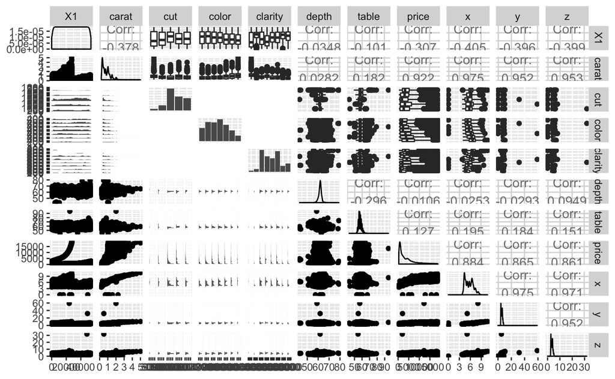

Looking at the above plot, it can be concluded that that **carat** is strongly correlated with the three dimensional varables. The correlation value between **carat** and dimensional varables is given in the following table:

|  | x | y | z |
| --- | --- | --- | --- |
| carat | 0.98 | 0.95 | 0.95 |

It is also interesting to compare each variable separately using the *ggplot( )* function. The plots are shown below.

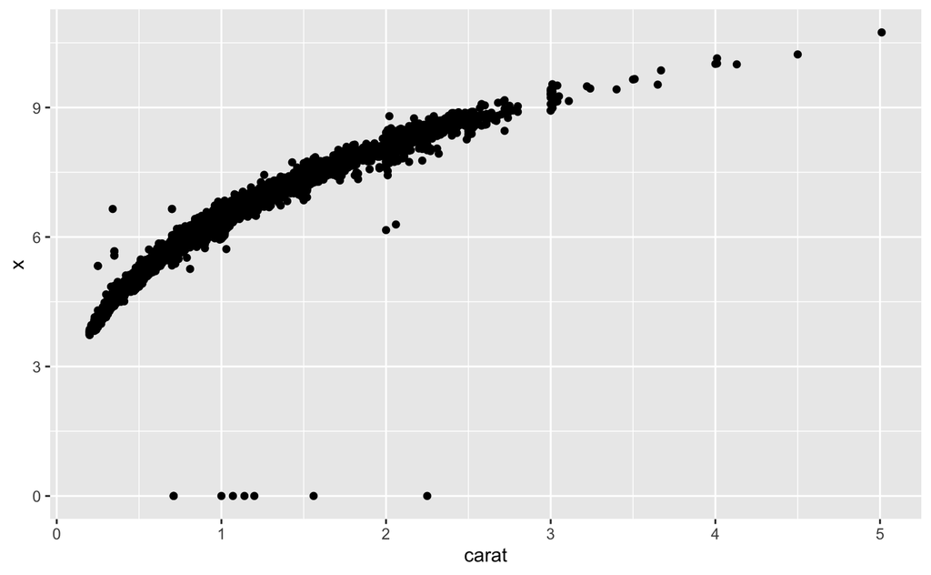

The plot between **carat** and **y**.

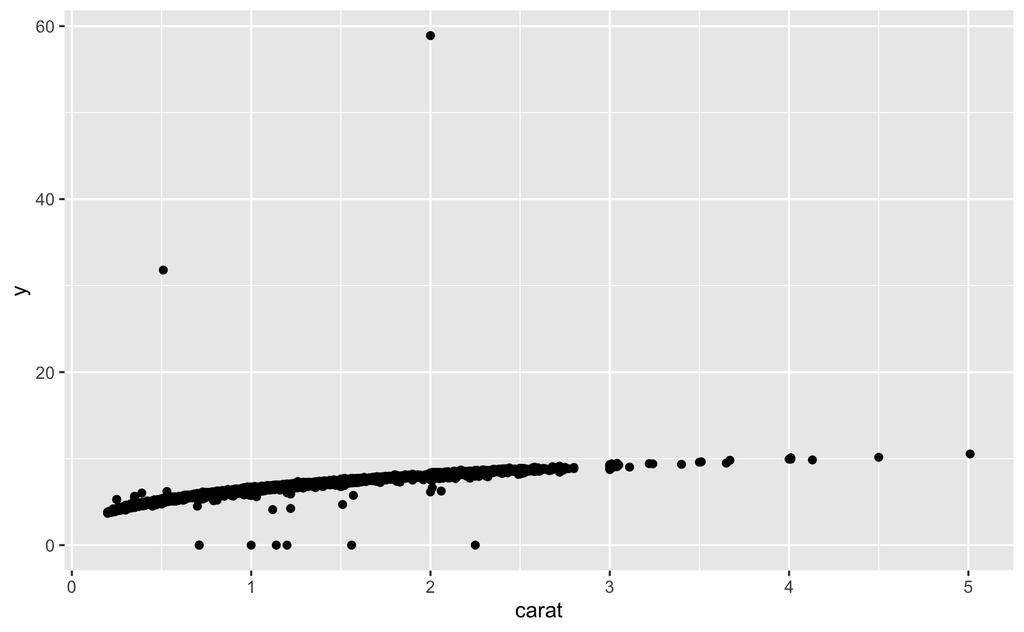

And finally, the plot of **carat** and the **z** variable.

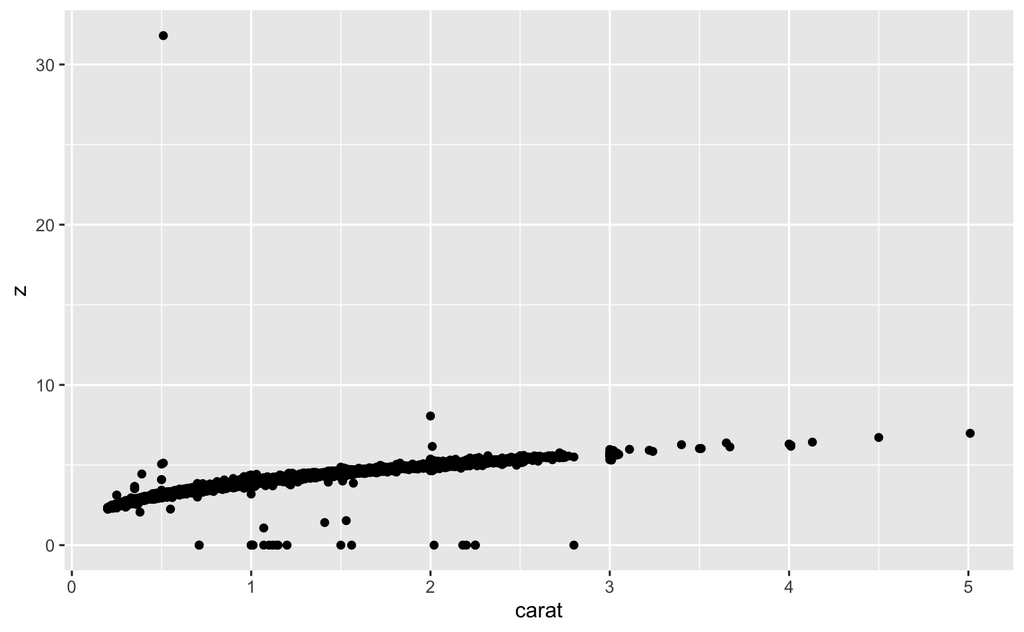

In the next study, the dimensional variables are dropped from the dataset.

```r
diamonds_data <- diamonds_data %>%
  select(-c(x,y,z))
```

The *ggpairs()* function is reconsidered in order to examine if there is any strong relation between the **price** and other variables from the dataset.

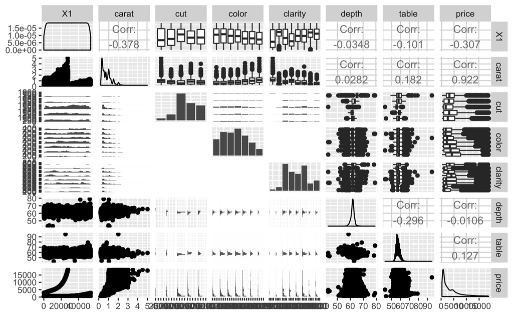

As shown, there is a possible relation between **price** and **carat** but the figure is not really clear. Therefore, a *ggplot()* visualisation is further applied to those two variables. As shown in the plot, **price** and **carat** variables are correlated - the correlation value is 0.92.

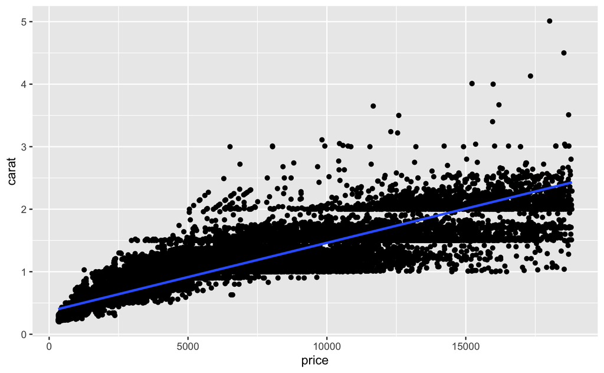

```r
diamonds_data %>%
  ggplot(aes(x = price, y = carat)) +
  geom_point() +
  geom_smooth(method = "lm", se = FALSE)
```

[output not shown]

Furter analysis is carried out where the **price** variable is now examined with the **depth** and **table** variables. The plots below show that those three variables are not correlated.

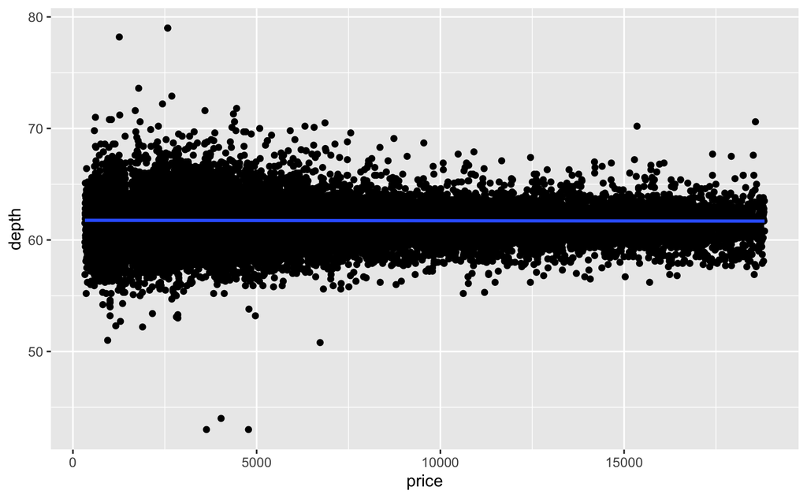

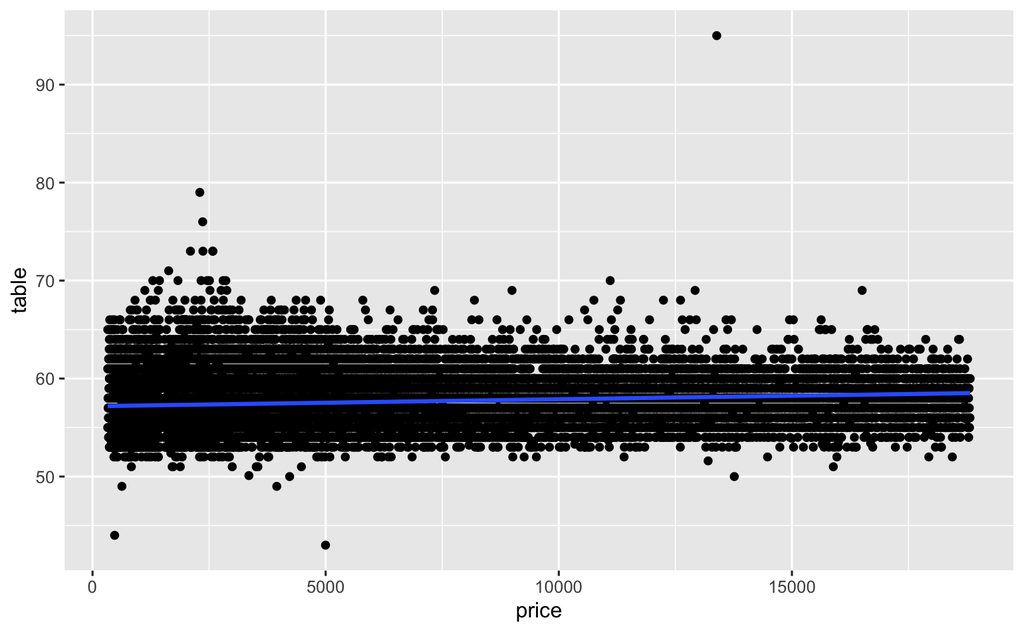

In the next study, the categorical predictors from the dataset, such as **colour**, **cut** and **quality** are examined. For example, the **cut** variable depends in the following elements, *Fair*, *Good*, *Very Good*, *Premium* and *Ideal*. Transforming the **cut** variable into a dummy variable, we end up having 4 new dummy variables. Note, the *Fair* variable is exluded from the data because it is depended from the other four dummy variables (e.g. a linear combination of four varibles can generate the *Fair* variable).

| X1 | carat | color | clarity | depth | table | price | cut_Good | cut_Ideal | cut_Premium | cut_Very Good |
| --- | --- | --- | --- | --- | --- | --- | --- | --- | --- | --- |
| 1 | 0.23 | E | SI2 | 61.5 | 55.0 | 326 | 0 | 1 | 0 | 0 |
| 2 | 0.21 | E | SI1 | 59.8 | 61.0 | 326 | 0 | 0 | 1 | 0 |
| 3 | 0.23 | E | VS1 | 56.9 | 65.0 | 327 | 1 | 0 | 0 | 0 |
| 4 | 0.29 | I | VS2 | 62.4 | 58.0 | 334 | 0 | 0 | 1 | 0 |
| 5 | 0.31 | J | SI2 | 63.3 | 58.0 | 335 | 1 | 0 | 0 | 0 |
| 6 | 0.24 | J | VVS2 | 62.8 | 57.0 | 336 | 0 | 0 | 0 | 1 |
| 7 | 0.24 | I | VVS1 | 62.3 | 57.0 | 336 | 0 | 0 | 0 | 1 |
| 8 | 0.26 | H | SI1 | 61.9 | 55.0 | 337 | 0 | 0 | 0 | 1 |
| 9 | 0.22 | E | VS2 | 65.1 | 61.0 | 337 | 0 | 0 | 0 | 0 |
| 10 | 0.23 | H | VS1 | 59.4 | 61.0 | 338 | 0 | 0 | 0 | 1 |

[output cut: 990 more lines]

The same transformartion process is applied to the **color** and **clarity** variable. There are in total 7 (6+1) dummy variables realted with **color** and 8 (7+1) dummy variables related with **clarity**.

```r
diamonds_color_dummy <- diamonds_data %>%
  dummy_cols(select = "color", remove_first_dummy = TRUE,
                        remove_selected_columns = TRUE)

diamonds_color_dummy
```

| X1 | carat | cut | clarity | depth | table | price | color_E | color_F | color_G | color_H | color_I | color_J |
| --- | --- | --- | --- | --- | --- | --- | --- | --- | --- | --- | --- | --- |
| 1 | 0.23 | Ideal | SI2 | 61.5 | 55.0 | 326 | 1 | 0 | 0 | 0 | 0 | 0 |
| 2 | 0.21 | Premium | SI1 | 59.8 | 61.0 | 326 | 1 | 0 | 0 | 0 | 0 | 0 |
| 3 | 0.23 | Good | VS1 | 56.9 | 65.0 | 327 | 1 | 0 | 0 | 0 | 0 | 0 |
| 4 | 0.29 | Premium | VS2 | 62.4 | 58.0 | 334 | 0 | 0 | 0 | 0 | 1 | 0 |
| 5 | 0.31 | Good | SI2 | 63.3 | 58.0 | 335 | 0 | 0 | 0 | 0 | 0 | 1 |
| 6 | 0.24 | Very Good | VVS2 | 62.8 | 57.0 | 336 | 0 | 0 | 0 | 0 | 0 | 1 |
| 7 | 0.24 | Very Good | VVS1 | 62.3 | 57.0 | 336 | 0 | 0 | 0 | 0 | 1 | 0 |
| 8 | 0.26 | Very Good | SI1 | 61.9 | 55.0 | 337 | 0 | 0 | 0 | 1 | 0 | 0 |
| 9 | 0.22 | Fair | VS2 | 65.1 | 61.0 | 337 | 1 | 0 | 0 | 0 | 0 | 0 |
| 10 | 0.23 | Very Good | VS1 | 59.4 | 61.0 | 338 | 0 | 0 | 0 | 1 | 0 | 0 |

[output cut: 990 more lines]

| X1 | carat | cut | color | depth | table | price | clarity_IF | clarity_SI1 | clarity_SI2 | clarity_VS1 | clarity_VS2 | clarity_VVS1 | clarity_VVS2 |
| --- | --- | --- | --- | --- | --- | --- | --- | --- | --- | --- | --- | --- | --- |
| 1 | 0.23 | Ideal | E | 61.5 | 55.0 | 326 | 0 | 0 | 1 | 0 | 0 | 0 | 0 |
| 2 | 0.21 | Premium | E | 59.8 | 61.0 | 326 | 0 | 1 | 0 | 0 | 0 | 0 | 0 |
| 3 | 0.23 | Good | E | 56.9 | 65.0 | 327 | 0 | 0 | 0 | 1 | 0 | 0 | 0 |
| 4 | 0.29 | Premium | I | 62.4 | 58.0 | 334 | 0 | 0 | 0 | 0 | 1 | 0 | 0 |
| 5 | 0.31 | Good | J | 63.3 | 58.0 | 335 | 0 | 0 | 1 | 0 | 0 | 0 | 0 |
| 6 | 0.24 | Very Good | J | 62.8 | 57.0 | 336 | 0 | 0 | 0 | 0 | 0 | 0 | 1 |
| 7 | 0.24 | Very Good | I | 62.3 | 57.0 | 336 | 0 | 0 | 0 | 0 | 0 | 1 | 0 |
| 8 | 0.26 | Very Good | H | 61.9 | 55.0 | 337 | 0 | 1 | 0 | 0 | 0 | 0 | 0 |
| 9 | 0.22 | Fair | E | 65.1 | 61.0 | 337 | 0 | 0 | 0 | 0 | 1 | 0 | 0 |
| 10 | 0.23 | Very Good | H | 59.4 | 61.0 | 338 | 0 | 0 | 0 | 1 | 0 | 0 | 0 |

[output cut: 990 more lines]

Going forward we’ll let R handle dummy variable creation for categorical predictors in regression fitting (remember lm() will generate the correct numbers of dummy levels automatically, absorbing one of the levels into the intercept as a reference level)

In the last study, a simple linear regression is used for the variables **price** and **carat**. The regression diagnostics is checked.

```r
model_price_carat <- lm(formula = price ~ carat, data = diamonds_data)
summary(model_price_carat)
```

```
Call:
lm(formula = price ~ carat, data = diamonds_data)

Residuals:
     Min       1Q   Median       3Q      Max
-18585.3   -804.8    -18.9    537.4  12731.7

Coefficients:
            Estimate Std. Error t value Pr(>|t|)
(Intercept) -2256.36      13.06  -172.8   <2e-16 ***
carat        7756.43      14.07   551.4   <2e-16 ***
---
Signif. codes:  0 ‘***’ 0.001 ‘**’ 0.01 ‘*’ 0.05 ‘.’ 0.1 ‘ ’ 1

Residual standard error: 1549 on 53938 degrees of freedom
Multiple R-squared:  0.8493,    Adjusted R-squared:  0.8493
F-statistic: 3.041e+05 on 1 and 53938 DF,  p-value: < 2.2e-16
```

And now the residulas are plotted. The Q-Q plot shows that the residuals diverge away from the line at both end-intervals.

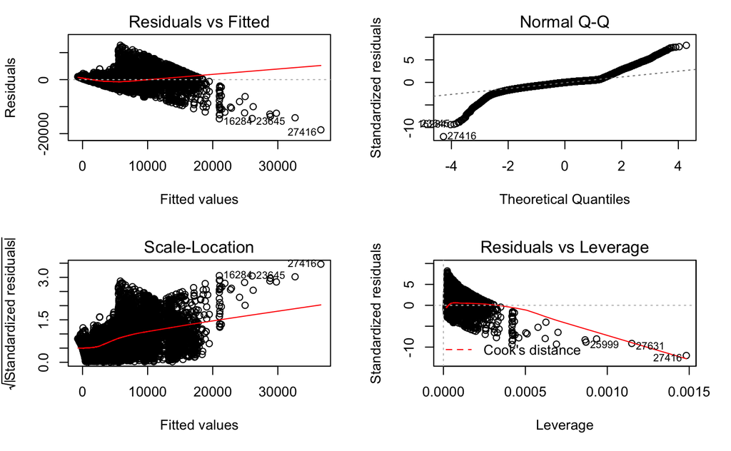

The *log( )* function is applied to the **price** and **carat** variables and a regression analysis and diagnostics are re-investigated.

[output not shown]

[output cut: 990 more lines]

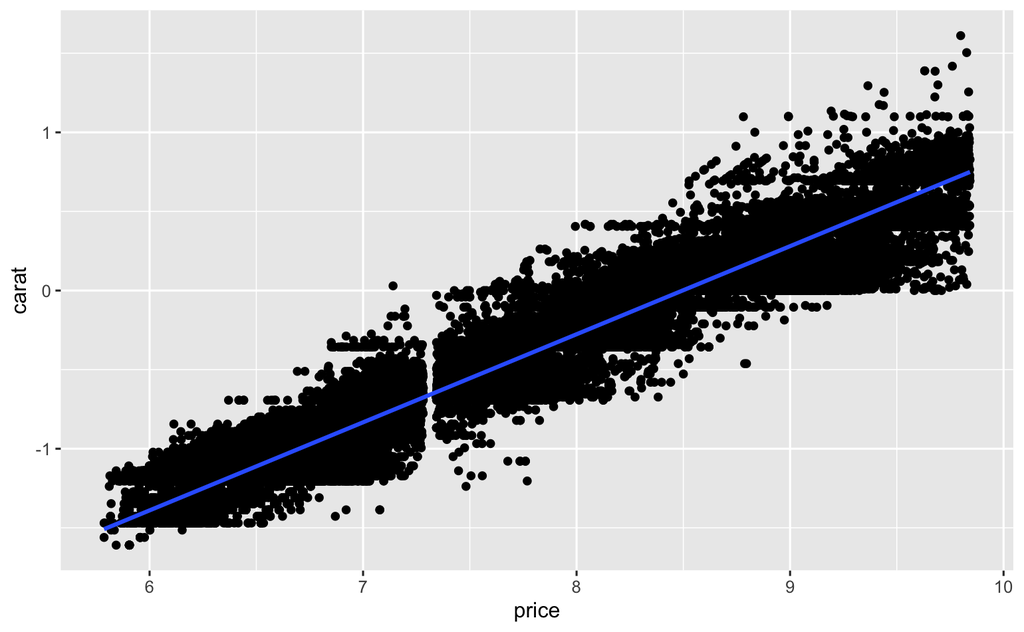

Run the diagnostics and plot the residual plots. As shown from the statistical summary, the coefficients b0 and b1 are significant not zero (p values = 0) and the *r^2* value is 0.93.

```r
model_price_carat_log <- lm(formula = price ~ carat, data = diamonds_data_log )
summary(model_price_carat_log)
```

```
Call:
lm(formula = price ~ carat, data = diamonds_data_log)

Residuals:
     Min       1Q   Median       3Q      Max
-1.50833 -0.16951 -0.00591  0.16637  1.33793

Coefficients:
            Estimate Std. Error t value Pr(>|t|)
(Intercept) 8.448661   0.001365  6190.9   <2e-16 ***
carat       1.675817   0.001934   866.6   <2e-16 ***
---
Signif. codes:  0 ‘***’ 0.001 ‘**’ 0.01 ‘*’ 0.05 ‘.’ 0.1 ‘ ’ 1

Residual standard error: 0.2627 on 53938 degrees of freedom
Multiple R-squared:  0.933, Adjusted R-squared:  0.933
F-statistic: 7.51e+05 on 1 and 53938 DF,  p-value: < 2.2e-16
```

The three residual plots now satisfy the necessary conditions.

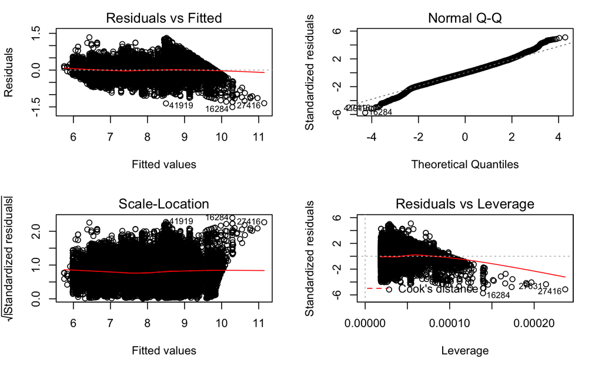

A new object, called **diamonds_data_log2** is created. It transforms the **price** and **carat** variables into a logarithmic scale and it includes the dummy **cut** variables.

```r
diamonds_data_log2 <- diamonds_cut_dummy %>%
  mutate(carat = log(carat)) %>%
  mutate(price = log(price))
```

```r
summary(model_price_carat_log2)
```

```
Call:
lm(formula = price ~ carat + cut_Ideal, data = diamonds_data_log2)

Residuals:
     Min       1Q   Median       3Q      Max
-1.48977 -0.16467 -0.00552  0.16094  1.38954

Coefficients:
            Estimate Std. Error t value Pr(>|t|)
(Intercept) 8.414335   0.001557 5405.12   <2e-16 ***
carat       1.690166   0.001929  876.05   <2e-16 ***
cut_Ideal   0.100100   0.002304   43.45   <2e-16 ***
---
Signif. codes:  0 ‘***’ 0.001 ‘**’ 0.01 ‘*’ 0.05 ‘.’ 0.1 ‘ ’ 1

Residual standard error: 0.2582 on 53937 degrees of freedom
Multiple R-squared:  0.9353,    Adjusted R-squared:  0.9353
F-statistic: 3.896e+05 on 2 and 53937 DF,  p-value: < 2.2e-16
```